# Episodic RL & Uncertainty: Experiment 4

Jonathan Nicholas and Daphna Shohamy

08/07/2018

*All analysis code is included at the end of the notebook*

The training phase of this experiment is identical to experiment one.

The testing phase of the experiment has a major change. Before each choice between an object and a circle, participants were shown the circle to be featured in an upcoming choice and were asked to indicate whether that circle was reliable or unreliable (as learned in the training phase).

```python
# Prepare data for plotting. All functions located at end of notebook

global exclude_response
global exclude_blur

# these parameters exclude very few people
exclude_response = .6
exclude_blur = 100
# Load the screentime data
int_data, exclude_pids = loadData(dType="interaction")
exclude_pids = map(int,exclude_pids)
# Load the experiment data
data = loadData(dType="experiment")[0]
# Clean the dataframe
agg_data = aggregateTestData(data=data,exclude_pids=exclude_pids)
# Calculate random performance
random_perf = gen_random_performance(data=data,n_sims=50)
# Get # of times clicked out of experiment
n_blurs = int_data[int_data.event == "blur"] \
            .groupby(['subjectID','event']) \
            .size() \
            .reset_index(name="n_blurs")
# Add # blurs to the cleaned data
agg_data['n_blurs'] = agg_data['pid'].apply(get_blurs)
# Subtract actual from random
agg_data['performance'] = agg_data['pid'].apply(get_relative_perf)
# Scale pOld by datapoints
agg_data['pOld_scaled'] = agg_data['pOld'] * agg_data['propResponse']

print("N= %s"%(len(agg_data.pid.unique()))) # Our final N
```

```
N= 47
```

# Train Phase

### Participants choose reliable > unreliable circles and high-value old > low-value old

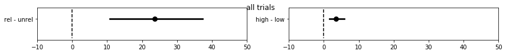

```python
train_choice_data = getTrainDataChoices()
plot_choice_differences(plt_type="all")
```

# Test phase

### Participants still do not transfer their preference for the reliable signal

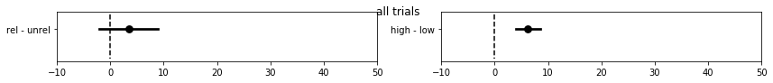

```python
test_choice_data = getTestDataChoices()

plot_choice_differences(plt_type="all",task_part="test")
```

### Participants that have higher accuracy during the incremental priming show a preference for the reliable signal

A median split was performed to investigate participants that indicate correct choices for circle reliability during the new priming portion of the task

```python
agg_data = perform_median_split()
```

```
PreTest median performance is 0.9133333333333333
N participants in low group: 24
N participants in high group: 23
```

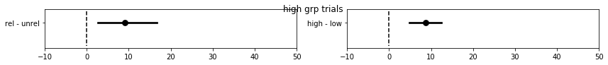

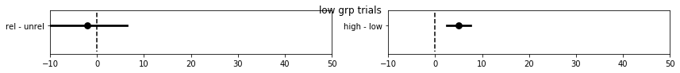

```python
medianGrp2Add = []
for pid in test_choice_data.pid.unique():
    pid_data = test_choice_data[test_choice_data.pid == pid]
    if pid in agg_data.pid.unique():
        medGrp = agg_data[agg_data.pid == pid].median_split.iloc[0]
        medianGrp2Add.append([medGrp] * len(pid_data))
    else:
        medianGrp2Add.append(["none"] * len(pid_data))
test_choice_data['median_split'] = [i for j in medianGrp2Add for i in j]

plot_choice_differences(plt_type="all",task_part="test",by_group="high")
plot_choice_differences(plt_type="all",task_part="test",by_group="low")
```

### There is no interaction between reliability and value across all participants

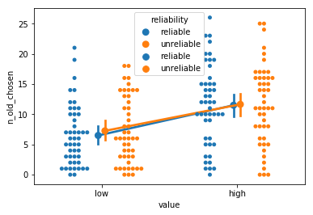

```python
sns.pointplot(x='value',y='n_old_chosen',
              hue='reliability',data=agg_data,
              order=['low','high'],dodge=True)
sns.swarmplot(x='value',y='n_old_chosen',
              hue='reliability',data=agg_data,
              order=['low','high'],dodge=True)
plt.show()
```

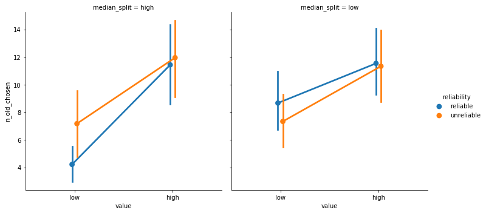

```python
sns.catplot(x='value',y='n_old_chosen',
              hue='reliability',data=agg_data,col="median_split",
              order=['low','high'],dodge=True,kind="point")
plt.show()
```

### There is a three-way interaction between accuracy during priming, object value, and incremental reliability: Participants with greater accuracy during incremental priming choose fewer low-valued old objects when the incremental signal is reliable.

- When the incremental signal is reliable, participants only choose high-valued episodes more frequently than low-valued episodes if they are aware that the incremental signal is reliable. This implies that participants are better at avoiding low-valued episodes if they are aware the incremental signal is reliable.
- When the incremental signal is unreliable, participants will choose high-valued old objects more frequently than low-valued old objects regardless of whether they are aware that the incremental signal is unreliable.

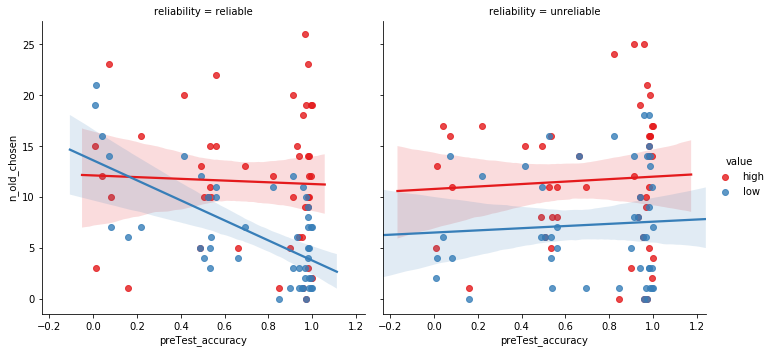

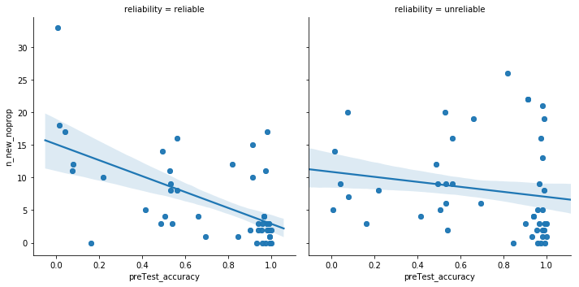

```python
sns.lmplot(x='preTest_accuracy',y='n_old_chosen',hue='value',
           col='reliability',data=agg_data,palette="Set1")
sns.lmplot(x='preTest_accuracy',y='n_new_noprop',col='reliability',data=agg_data)
```

```python
# Hierarchical linear modeling

import statsmodels.api as sm
import statsmodels.formula.api as smf

model = "n_old_chosen ~ n_blurs + propResponse + performance + preTest_accuracy*value*reliability"

md = smf.mixedlm(model,agg_data, groups=agg_data["pid"])

mdf = md.fit()
print(mdf.summary())
```

```
                               Mixed Linear Model Regression Results
===================================================================================================
Model:                           MixedLM              Dependent Variable:              n_old_chosen
No. Observations:                188                  Method:                          REML
No. Groups:                      47                   Scale:                           15.0226
Min. group size:                 4                    Likelihood:                      -539.3088
Max. group size:                 4                    Converged:                       Yes
Mean group size:                 4.0
---------------------------------------------------------------------------------------------------
                                                        Coef.  Std.Err.   z    P>|z|  [0.025 0.975]
---------------------------------------------------------------------------------------------------
Intercept                                                3.782   34.167  0.111 0.912 -63.183 70.748
value[T.low]                                             1.484    1.952  0.760 0.447  -2.342  5.309
reliability[T.unreliable]                               -1.330    1.952 -0.682 0.495  -5.156  2.495
value[T.low]:reliability[T.unreliable]                  -5.766    2.760 -2.089 0.037 -11.176 -0.355
n_blurs                                                 -0.045    0.073 -0.616 0.538  -0.189  0.099
propResponse                                             9.575   34.969  0.274 0.784 -58.963 78.112
performance                                             27.078   10.523  2.573 0.010   6.453 47.703
preTest_accuracy                                        -3.326    2.624 -1.268 0.205  -8.469  1.816
preTest_accuracy:value[T.low]                           -8.989    2.469 -3.641 0.000 -13.828 -4.150
preTest_accuracy:reliability[T.unreliable]               2.051    2.469  0.831 0.406  -2.788  6.890
preTest_accuracy:value[T.low]:reliability[T.unreliable]  8.849    3.491  2.535 0.011   2.006 15.692
Group Var                                               15.295    1.228
===================================================================================================
```

#### Speculation about possible explanations

##### You will default to the reliable incremental signal unless you are very certain about the episode being valuable

**This result implies that both the certainty of the incremental controller and the episodic controller play a role in arbitrating choice.** Determining that an incremental signal is reliable may allow for more resources to determine whether an episode is 1) previously seen and 2) valuable. Perhaps this is because an easy heuristic can be employed: choose incrementally unless the episode is highly valuable (In this case, more valuable than the incremental signal). What about more continuous value? How much more valuable does an episode need to be in order to be remembered using this heuristic?

##### Having an unreliable incremental signal (either being unaware or realizing it is unreliable) may lead to less selectivity

Determining that an incremental signal is unreliable does not seem to change baseline behavior here, which is to choose episodes more frequently and less selectively. Thus, if you don't have a reliable incremental signal (e.g. you aren't aware of it or you are and you've determined it isn't reliable) then you are going to choose episodes less selectively. This could be interpreted several ways. Perhaps it is that you are more willing to risk an episodic choice since choosing incrementally is less safe. Another explanation could be that it is only worth retrieiving less rewarding episodes in order to avoid them if the reliability heuristic (mentioned above) is available.

##### People who are better at priming accuracy are also just better at the task/are trying harder

It is also possible that this is just an artifact of performance (and people will perform better when they are more certain), although including performance as a covariate does not change the findings.

### Which choice strategies best explain behavior?

```python
strategies = gen_strategy(data=data,strategy='choosehighold')
strategies['chooseold'] = gen_strategy(data=data,strategy='chooseold')['chooseold']
strategies['chooserel'] = gen_strategy(data=data,strategy='chooserel')['chooserel']
strategies['choosecircle'] = gen_strategy(data=data,strategy='choosecircle')['choosecircle']
strategies['chooseobject'] = gen_strategy(data=data,strategy='chooseobject')['chooseobject']
strategies['random'] = gen_strategy(data=data,strategy='random')['random']

strategyDf = pd.melt(strategies, id_vars=['pid'], value_vars=['choosehighold',
                                                              'chooseold',
                                                              'chooserel',
                                                              'choosecircle',
                                                              'chooseobject',
                                                              'random'])
```

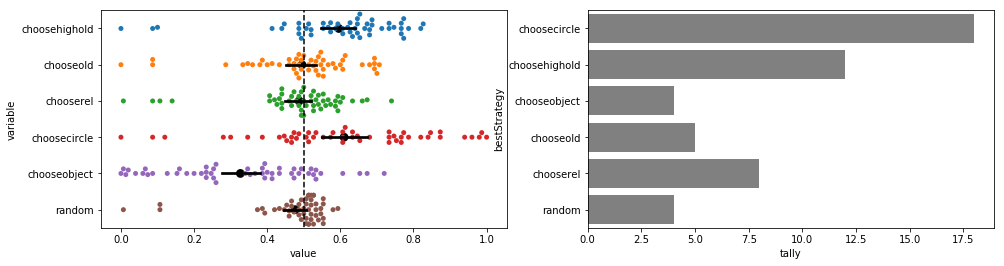

```python
f, ax = plt.subplots(1,2,figsize=(16,4))

sns.pointplot(y='variable',x='value',data=strategyDf,color='black',join=False,zorder=2,ax=ax[0])
sns.swarmplot(y='variable',x='value',data=strategyDf,zorder=1,ax=ax[0])
ax[0].plot((0.5,0.5),(-1,9),'k--')

best_strategies = get_best_strategy(strategyDf)

sns.barplot(y="bestStrategy", x="tally", data=best_strategies,color='grey',ax=ax[1])
plt.show()
```

- ~40% choose only circles
- ~25% choose high old
- ~20% choose the reliable circle

However, we also see that now, after forcing participants to attend to the reliability of a circle (as they learned it), many individuals have behavior that is best explained by a strategy that we haven't seen much of before, which is to choose the circle stimulus only if it is reliable. This is interesting because we now have evidence that some participants are making choices considering the incremental stimulus first, rather than the objects, which is necessary for our hypothesis to be tested.

We can see at the group level that this strategy does NOT explain a majority of participants' choices.

### What strategies do high accuracy individuals use?

Amongst these individuals who attended to the incremental signal, we might expect to see an effect only for those who also consider the object (e.g. the choosehighold participants)

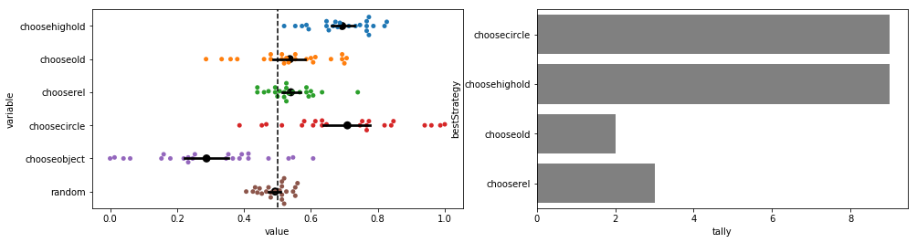

```python
highGrp = list(agg_data[agg_data.median_split == "high"].pid.unique())
highStrategyDf = strategyDf[strategyDf.pid.isin(highGrp)]

f, ax = plt.subplots(1,2,figsize=(16,4))

sns.pointplot(y='variable',x='value',data=highStrategyDf,color='black',join=False,zorder=2,ax=ax[0])
sns.swarmplot(y='variable',x='value',data=highStrategyDf,zorder=1,ax=ax[0])
ax[0].plot((0.5,0.5),(-1,9),'k--')

best_strategies = get_best_strategy(highStrategyDf)

sns.barplot(y="bestStrategy", x="tally", data=best_strategies,color='grey',ax=ax[1])
plt.show()
```

These individuals use primarily the choosecircle and choosehighold strategies at an equal rate.

### High-accuracy choosehighold individuals do not show the interaction

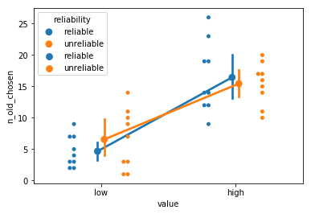

```python
aggHighStrat = agg_data[agg_data.pid.isin(highGrp)]

sns.pointplot(x='value',y='n_old_chosen',hue='reliability',
              data=aggHighStrat[aggHighStrat.bestStrategy == "choosehighold"],
              order=['low','high'],dodge=True,)
sns.swarmplot(x='value',y='n_old_chosen',hue='reliability',
              data=aggHighStrat[aggHighStrat.bestStrategy == "choosehighold"],
              order=['low','high'],dodge=True,)
plt.show()
```

### In general, do individuals that show greater sensitivity to the incremental signal choose more old objects in old v. unreliable trials?

- Since individual performance in this task varies widely, we might expect a more subtle effect to arise where only those who are choosing a greater # of reliable circles also choose more old objects over unreliable circles

```
(-0.674149048095529, 2.051045836010644e-07)
(-0.38485114742474447, 0.007560222460374191)
(-0.7290861566037594, 6.193144940634087e-09)
```

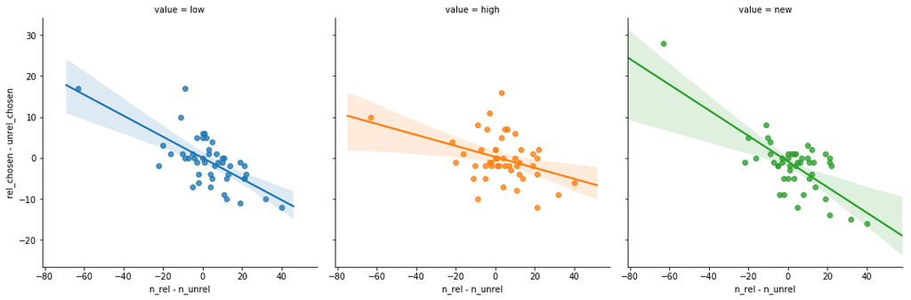

```python
relDiffDf = get_senstivity_relationship()

sns.lmplot(x="n_rel - n_unrel",y="rel_chosen - unrel_chosen", hue='value', col="value",data=relDiffDf)

from scipy.stats import pearsonr
print(pearsonr(relDiffDf[relDiffDf.value == "low"]["n_rel - n_unrel"],
               relDiffDf[relDiffDf.value == "low"]["rel_chosen - unrel_chosen"]))
print(pearsonr(relDiffDf[relDiffDf.value == "high"]["n_rel - n_unrel"],
               relDiffDf[relDiffDf.value == "high"]["rel_chosen - unrel_chosen"]))
print(pearsonr(relDiffDf[relDiffDf.value == "new"]["n_rel - n_unrel"],
               relDiffDf[relDiffDf.value == "new"]["rel_chosen - unrel_chosen"]))
```

Participants who are more sensitive to the reliability difference (e.g. choose more rel than unrel) also choose more objects when choices are between an object and an unreliable circle v. an object and a reliable circle.

This is expected, and would only be interesting if the relationship held for old objects but not new objects. However, we can see from the above that this is not the case.

# Conclusions

- During Training:
  - Participants show a preference for reliable > unreliable circles and high old > low old. This replicates training effects from previous experiments, demonstrating that people can learn the task.
- During Testing:
  - Participants in general follow the pattern from the previous experiments, where they demonstrate a preference for high old > low old but not reliable > unreliable. However, if we split participants by their accuracy on circle priming, we see that those who correctly indicate circle identity do show the reliable > unreliable choice preference.
  - There is no interaction between value and reliability.
  - There is a three-way interaction between value, reliability, and accuracy during priming such that individuals who are more accurate choose fewer low-valued objects when the incremental signal is reliable.
  - Most participants follow either the choose circle or choosehighold strategy as before. We also see an indication that priming with circle identity influences choices with the emergence of a strategy where some participants choose mostly based on whether a circle is reliable or not.
  - Participants that choose more reliable > unreliable circles also choose more objects when choosing between an object and an unreliable circle, but this is not greater for old objects compared to new objects.

##### All analysis code included below

```python
# Importing packages
%matplotlib inline
from __future__ import division
import warnings, os
warnings.filterwarnings('ignore')
import numpy as np
import pandas as pd
import matplotlib.pyplot as plt
import seaborn as sns

def loadData(dType=None,dataDir="/Users/jonathan/shohamylab/jspych-exps/data/exp4",fileType="stateData"):
    data, exclude_pids = [], []
    dataFiles = [d for d in os.listdir(dataDir) if dType in d]
    for f in dataFiles:
        subData = pd.read_csv(os.path.join(dataDir,f))
        if dType == "interaction":
            if len(subData[subData.event == 'blur']) >= exclude_blur:
                exclude_pids.append(f.split('_')[0])
            subData['subjectID'] = [f.split('_')[0]] * len(subData)
        elif dType == "experiment":
            bonus = float(f.split('_')[2].replace('bonus',''))
            subData['bonus'] = [bonus] * len(subData)
        data.append(subData)
    data = pd.concat(data,ignore_index=True)
    return data, exclude_pids

def get_only_acc_trials(pid=None):

    inData = data[(data.test_part == "preTest") &
                  (data.subjectID == pid) &
                  (data.trial_number <= 150)]
    preTestAcc = []
    for i_row, row in inData.iterrows():
        if row.deck_type == "orange":
            if row.choice == "Unrel":
                accuracy = 1
            else:
                accuracy = 0
        elif row.deck_type == "blue":
            if row.choice == "Rel":
                accuracy = 1
            else:
                accuracy = 0
        preTestAcc.append(accuracy)
    inData["accuracy"] = preTestAcc
    acc_trials = list(inData[inData.accuracy == 1].trial_number)
    return acc_trials

def get_preTest_accuracy():

    preTestData = data[(data.test_part == "preTest") &
                       (data.trial_number <= 150)]
    preTestAcc = []
    for i_row, row in preTestData.iterrows():
        if row.deck_type == "orange":
            if row.choice == "Unrel":
                accuracy = 1
            else:
                accuracy = 0
        elif row.deck_type == "blue":
            if row.choice == "Rel":
                accuracy = 1
            else:
                accuracy = 0
        preTestAcc.append(accuracy)
    preTestData["accuracy"] = preTestAcc

    preTestAcc = {'pid':[],'accuracy':[]}
    for pid in preTestData.subjectID.unique():
        pidData = preTestData[preTestData.subjectID == pid]
        preTestAcc['pid'].append(pid)
        preTestAcc['accuracy'].append(pidData["accuracy"].mean())
    preTestAcc = pd.DataFrame.from_dict(preTestAcc)

    return preTestAcc

def get_blurs(x):
    if str(x) in n_blurs.subjectID.unique():
        pid_blurs = n_blurs[n_blurs.subjectID == str(x)].n_blurs.iloc[0]
        return pid_blurs
    else:
        # if not there, then they don't have any blurs
        return 0

def get_relative_perf(x):
    # calculate their performance relative to what is expected based on random guessing
    rand_perf = random_perf[random_perf.pid == x].random_test.iloc[0]
    actual_earnings = random_perf[random_perf.pid == x].actual_earnings.iloc[0]
    rel_perf = (actual_earnings*0.01) - (rand_perf*0.01)

    return rel_perf

def aggregateTestData(data=None, exclude_pids=None, acc_reliable_only=False):

    pids = data.subjectID.unique()

    dOut = {'reliability':[],'value':[],'pOld':[],
            'pid':[],'bonus':[],'propResponse':[],
            'mean_rt':[],'n_rel':[],'n_unrel':[],'n_circle':[],'n_object':[],
            'n_old_high':[],'n_old_low':[],'n_new':[],'rt_old':[],'rt_new':[],
           'rt_rel':[],'rt_unrel':[],'rt_circle':[],'rt_object':[],'n_old_chosen':[],
           'n_new_noprop':[],'n_rel_noprop':[],'n_unrel_noprop':[]}
    for pid in pids:

        train_data = data[(data.test_part == 'train') & (data.subjectID == pid)]
        test_data = data[(data.test_part == 'test') &
                         (data.subjectID == pid) &
                         (data.trial_number <= 150)]
        if acc_reliable_only:

            acc_trials = get_only_acc_trials(pid=pid)

            try:
                test_data = test_data[test_data.trial_number.isin(acc_trials)]
                if len(test_data) == 0:
                    exclude_pids.append(pid)
            except:
                exclude_pids.append(pid)

        bonus = test_data.bonus.mean()

        nTrials = len(train_data)+len(test_data)

        cleaned_train = train_data[train_data.choice != 'no_response']
        cleaned_test = test_data[test_data.choice != 'no_response']

        nResponded = len(cleaned_train)+len(cleaned_test)
        proportionResponse = nResponded/nTrials

        old_test = cleaned_test[cleaned_test.old_trial == True]
        old_chosen = old_test[old_test.choice == 'object']

        if proportionResponse >= exclude_response and pid not in exclude_pids:

            colors = ['blue','orange']
            values = ['1.20','0.00']

            for c in colors:
                for v in values:
                    nTotal = len(old_test[(old_test.deck_type == c) & \
                                          (old_test.old_value == v)])
                    nChosen = len(old_chosen[(old_chosen.deck_type == c) & \
                                             (old_chosen.old_value == v)])

                    # number of object trials chosen
                    nOldHigh = len(cleaned_test[(cleaned_test.choice == "object") & \
                                                (cleaned_test.old_trial == True) & \
                                                (cleaned_test.old_value == '1.20')])
                    nOldLow = len(cleaned_test[(cleaned_test.choice == "object") & \
                                               (cleaned_test.old_trial == True) & \
                                               (cleaned_test.old_value == '0.00')])

                    nNew = len(cleaned_test[(cleaned_test.choice == "object") & \
                                            (cleaned_test.old_trial == False) & \
                                            (cleaned_test.deck_type == c)])
                    nObject = nOldHigh+nOldLow+nNew
```

```python
                    rtOld = cleaned_test[(cleaned_test.choice == "object") & \
                                            (cleaned_test.old_trial == True)].rt.mean()
                    rtNew = cleaned_test[(cleaned_test.choice == "object") & \
                                            (cleaned_test.old_trial == False)].rt.mean()
                    rtObject = rtOld+rtNew

                    # number of circle trials chosen
                    nReliable = len(cleaned_test[(cleaned_test.choice == "blue")])
                    nUnreliable = len(cleaned_test[(cleaned_test.choice == "orange")])
                    nCircle = nReliable+nUnreliable

                    rtReliable = cleaned_test[cleaned_test.choice == "blue"].rt.mean()
                    rtUnreliable = cleaned_test[cleaned_test.choice == "orange"].rt.mean()
                    rtCircle = np.mean([rtReliable,rtUnreliable])

                    nTotalChoices = nObject+nCircle
                    nNewNoProp = nNew
                    nRelNoProp = nReliable
                    nUnrelNoProp = nUnreliable
                    # set in terms of proportions
                    nObject = nObject/nTotalChoices
                    nNew = nNew/nTotalChoices
                    nOldHigh = nOldHigh/nTotalChoices
                    nOldLow = nOldLow/nTotalChoices
                    nCircle = nCircle/nTotalChoices
                    nReliable = nReliable/nTotalChoices
                    nUnreliable = nUnreliable/nTotalChoices

                    # number of old chosen/number of total old trials
                    try:
                        pOld = nChosen/nTotal
                    except:
                        pOld = np.nan
                    nOldChosen = nChosen

                    # mean RT for when the old items are chosen
                    meanRT = old_test[(old_test.deck_type == c) & \
                                    (old_test.old_value == v)].rt.mean()

                    if c == 'blue':
                        rel = 'reliable'
                    else:
                        rel = 'unreliable'

                    if v == '1.20':
                        val = 'high'
                    else:
                        val = 'low'

                    dOut['reliability'].append(rel)
                    dOut['value'].append(val)
                    dOut['pOld'].append(pOld)
                    dOut['pid'].append(pid)
                    dOut['bonus'].append(bonus)
                    dOut['propResponse'].append(proportionResponse)
                    dOut['mean_rt'].append(meanRT)
                    dOut['n_rel'].append(nReliable)
                    dOut['n_unrel'].append(nUnreliable)
                    dOut['n_circle'].append(nCircle)
                    dOut['n_old_high'].append(nOldHigh)
                    dOut['n_old_low'].append(nOldLow)
                    dOut['n_new'].append(nNew)
                    dOut['n_new_noprop'].append(nNewNoProp)
                    dOut['n_rel_noprop'].append(nRelNoProp)
                    dOut['n_unrel_noprop'].append(nUnrelNoProp)
                    dOut['n_object'].append(nObject)
                    dOut['n_old_chosen'].append(nOldChosen)
                    dOut['rt_rel'].append(rtReliable)
                    dOut['rt_unrel'].append(rtUnreliable)
                    dOut['rt_circle'].append(rtCircle)
                    dOut['rt_old'].append(rtOld)
                    dOut['rt_new'].append(rtNew)
                    dOut['rt_object'].append(rtObject)


    dOut = pd.DataFrame.from_dict(dOut)
    return dOut

def gen_random_performance(data=None,n_sims=None):

    # Let's try and model guessing behavior
    # e.g. how much would we expect them to earn if they were just guessing?
    import random

    test_data = data[(data.test_part == 'test')]

    random_perf = {'pid':[],'random_test':[],'actual_earnings':[]}
    for pid in test_data.subjectID.unique():

        pid_data = test_data[test_data.subjectID == pid]

        earnings = pid_data[pid_data.earned != 'none'].earned
        total_earnings = np.sum(pd.to_numeric(earnings))

        sim_earnings = []
        for sim in range(n_sims):

            test_earnings = 0

            for i_row, row in pid_data.iterrows():

                reliableSample = np.round_(np.random.normal(0.6,0.05,1),decimals=2)
                unreliableSample = np.round_(np.random.normal(0.6,0.2,1),decimals=2)

                old_val = row.old_value
                deck_type = row.deck_type

                if old_val == 'none':
                    obj_val = random.choice([0,1.2])
                elif old_val == '0.00':
                    obj_val = 0
                elif old_val == '1.20':
                    obj_val = 1.2

                if deck_type == 'blue':
                    deck_val = reliableSample[0]
                else:
                    deck_val = unreliableSample[0]

                test_earnings+=random.choice([deck_val,obj_val])

            sim_earnings.append(test_earnings)

        random_perf['pid'].append(pid)
        random_perf['random_test'].append(np.mean(sim_earnings))
        random_perf['actual_earnings'].append(total_earnings)

    random_perf = pd.DataFrame.from_dict(random_perf)

    return random_perf

def gen_strategy(data=None,strategy=None,get_only_acc=False):
    to_exclude = []

    # Model object-centric choice strategy
    # Choose an object only if it is high-value old
    import random

    test_data = data[(data.test_part == 'test')]

    perf = {'pid':[],strategy:[]}
    for pid in test_data.subjectID.unique():

        pid_data = test_data[test_data.subjectID == pid]
        pid_data = pid_data[pid_data.trial_number <= 150]

        if get_only_acc:

            acc_trials = get_only_acc_trials(pid=pid)

            try:
                pid_data = pid_data[pid_data.trial_number.isin(acc_trials)]
                if len(pid_data) == 0:
                    to_exclude.append(pid)
            except:
                to_exclude.append(pid)
```

```python
        if pid not in to_exclude:
            earnings = pid_data[pid_data.earned != 'none'].earned
            total_earnings = np.sum(pd.to_numeric(earnings))

            agreement = 0
            for i_row, row in pid_data.iterrows():

                old_val = row.old_value
                deck_type = row.deck_type

                if strategy == 'choosehighold':

                    if old_val == '1.20':
                        sim_choice = 'object'
                    else:
                        sim_choice = 'deck'

                elif strategy == 'choosehighandnew':
                    if old_val == '1.20' or old_val == 'none':
                        sim_choice = 'object'
                    else:
                        sim_choice = 'deck'

                elif strategy == 'chooseold':

                    if old_val == '1.20' or old_val == '0.00':
                        sim_choice = 'object'
                    else:
                        sim_choice = 'deck'

                elif strategy == 'choosecircle':

                    sim_choice = 'deck'

                elif strategy == 'chooseobject':

                    sim_choice = 'object'

                elif strategy == 'chooserel':

                    if deck_type == 'blue':
                        sim_choice = 'deck'
                    else:
                        sim_choice = 'object'

                elif strategy == 'chooseunrel':

                    if deck_type == 'orange':
                        sim_choice = 'deck'
                    else:
                        sim_choice = 'object'

                elif strategy == 'random':

                    sim_choice = random.choice(['object','deck'])

                if sim_choice == 'object':
                    if row.choice =='object':
                        agree = 1
                    else:
                        agree = 0
                elif sim_choice == 'deck':
                    if row.choice == 'blue' or row.choice == 'orange':
                        agree = 1
                    else:
                        agree = 0

                agreement+=agree

            agreement = agreement/len(pid_data)

            perf['pid'].append(pid)
            perf[strategy].append(agreement)

    perf = pd.DataFrame.from_dict(perf)

    return perf

def get_best_strategy(strategyDf):
    global s
    s = {'pid':[],'bestStrategy':[],'value':[]}
    for pid in strategyDf.pid.unique():
        pidData = strategyDf[strategyDf.pid == pid]
        maxRow = pidData.loc[pidData.value.argmax()]
        bestStrategy = maxRow.variable
        maxValue = maxRow.value
        s['pid'].append(pid)
        s['bestStrategy'].append(bestStrategy)
        s['value'].append(maxValue)
    s = pd.DataFrame.from_dict(s)
    s1 = s.groupby('bestStrategy').size().reset_index(name='tally')
    return s1

def plt_indiv_strategies(x=None,y=None,corr=None):

    r, axes = plt.subplots(1,2,figsize=(10,4))

    r = sns.regplot(y=y,x=x,data=strategies,ax=axes[0])
    r.set_xlim(0,1)
    r.set_ylim(0,1)
    if corr == "negative":
        axes[0].plot((1,1),(1,1),'k--',)
    else:
        axes[0].plot((0,1),(0,1),'k--',)

    strategies['%s - %s'%(x,y)] = strategies[y] - strategies[x]
    sns.swarmplot(strategies['%s - %s'%(x,y)],zorder=1,ax=axes[1])
    f = sns.pointplot(strategies['%s - %s'%(x,y)],color='black',zorder=2,ax=axes[1])
    f.set_ylim(-0.25,0.25)
    axes[1].plot((0,0),(-1,1),'k--')
    plt.show()

def get_performance_by_strategy(use_only_acc_trials=False):
    if use_only_acc_trials:
        d = aggAccOnly
    else:
        d = agg_data
    s3 = []
    for pid in d.pid.unique():
        pid_data = d[d.pid == pid]
        s3.append([strategies[strategies.pid == pid] \
                  ['choosecircle - choosehighold'].iloc[0]] * len(pid_data))
    s3 = [i for j in s3 for i in j]
    d['highold - circle'] = s3


    s2 = []
    for pid in d.pid.unique():
        pid_data = d[d.pid == pid]
        s2.append([s[s.pid == pid].bestStrategy.iloc[0]] * len(pid_data))
    s2 = [i for j in s2 for i in j]
    d['bestStrategy'] = s2

    return d

def melt_choice_df(variables=[],col_name="None",data_subset=None,use_only_acc_trials=False):

    if data_subset == 'highvalobj':
        if not use_only_acc_trials:
            full_data = agg_data[agg_data.bestStrategy == "choosehighold"]
        else:
            full_data = aggAccOnly[aggAccOnly.bestStrategy == "choosehighold"]
    if data_subset == 'chooserel':
        if not use_only_acc_trials:
            full_data = agg_data[agg_data.bestStrategy == "chooserel"]
        else:
            full_data = aggAccOnly[aggAccOnly.bestStrategy == "chooserel"]
    else:
        if not use_only_acc_trials:
            full_data = agg_data
        else:
            full_data = aggAccOnly

    plt_data = pd.melt(full_data, id_vars=['pid'], value_vars=variables)
    plt_data = plt_data.groupby(['pid','variable']).value.mean().reset_index(name=col_name)

    perf = []
    for pid in plt_data.pid.unique():
        d_length = len(plt_data[plt_data.pid == pid])
        perf.append([full_data[full_data.pid == pid].performance.iloc[0]] * d_length)
    perf = [i for j in perf for i in j]
    plt_data['performance'] = perf

    return plt_data

def plot_choice_differences(plt_type=None,task_part=None,by_group=None):
    if plt_type != "all":
        plt_data = train_choice_data[train_choice_data.trial_type == plt_type]
    else:
        if task_part == "test":
            plt_data = test_choice_data
        else:
            plt_data = train_choice_data

    if by_group == "high":
        plt_data = test_choice_data[test_choice_data.median_split == "high"]
        plt_type = "high grp"
    elif by_group == "low":
        plt_data = test_choice_data[test_choice_data.median_split == "low"]
        plt_type = "low grp"

    rel_unrel_diff = np.array(plt_data[plt_data.choice_type == "n_rel_chosen"].n_chosen) - \
                     np.array(plt_data[plt_data.choice_type == "n_unrel_chosen"].n_chosen)
```

```python
    high_low_diff = np.array(plt_data[plt_data.choice_type == "n_highold_chosen"].n_chosen) - \
                    np.array(plt_data[plt_data.choice_type == "n_lowold_chosen"].n_chosen)

    f, ax = plt.subplots(1,2,figsize=(14,1))
    plt.suptitle("%s trials"%(plt_type))
    # sns.swarmplot(rel_unrel_diff,["rel - unrel"] * len(rel_unrel_diff),ax=ax[0])
    sns.pointplot(rel_unrel_diff,["rel - unrel"] * len(rel_unrel_diff),ax=ax[0],color='k')
    ax[0].plot((0,0),(-1,2),'k--')

    # sns.swarmplot(high_low_diff,["high - low"] * len(rel_unrel_diff),ax=ax[1])
    sns.pointplot(high_low_diff,["high - low"] * len(rel_unrel_diff),ax=ax[1],color='k')
    ax[1].plot((0,0),(-1,2),'k--')

    for a in ax:
        a.set_xlim(-10,50)

    plt.show()


def getTestDataChoices():

    test_data = data[data.test_part == "test"]
    test_data = test_data[test_data.choice != 'no_response']

    dOut = {'pid':[],'choice_type':[],'n_chosen':[]}

    for pid in test_data.subjectID.unique():

        pid_data = test_data[test_data.subjectID == pid]
        trial_data = pid_data
        trial_data.loc[trial_data['choice'].str.contains('object'), 'choice'] = 'object'

        old_data = trial_data[trial_data.old_trial == True]

        old_chosen = old_data[old_data.choice == "object"]

        new_chosen = trial_data[(trial_data.choice == "object") & \
                                (trial_data.old_trial == False)]

        n_old_chosen = len(old_chosen)
        n_new_chosen = len(new_chosen)
        n_highold_chosen = len(old_chosen[old_chosen.earned == "1.20"])
        n_lowold_chosen = len(old_chosen[old_chosen.earned == "0.00"])
        n_unrel_chosen = len(trial_data[trial_data.choice == "orange"])
        n_rel_chosen = len(trial_data[trial_data.choice == "blue"])

        choice_values = [n_old_chosen,n_rel_chosen,n_unrel_chosen,
                         n_highold_chosen,n_lowold_chosen,n_new_chosen]
        for i, choiceType in enumerate(['n_old_chosen',
                                        'n_rel_chosen',
                                        'n_unrel_chosen',
                                        'n_highold_chosen',
                                        'n_lowold_chosen',
                                        'n_new_chosen']):


            dOut['choice_type'].append(choiceType)
            dOut['n_chosen'].append(choice_values[i])
            dOut['pid'].append(pid)

    dOut = pd.DataFrame.from_dict(dOut)
    return dOut


def getTrainDataChoices():

    train_data = data[data.test_part == "train"]
    train_data = train_data[train_data.choice != 'no_response']

    dOut = {'pid':[],'trial_type':[],
            'choice_type':[],'n_chosen':[]}

    trial_types = ["object","deck","both"]

    for pid in train_data.subjectID.unique():

        pid_data = train_data[train_data.subjectID == pid]
        pid_data.loc[pid_data['choice'].str.contains('object'), 'choice'] = 'object'

        for tType in trial_types:

            if tType == "object":
                trial_data = pid_data[pid_data.choice == "object"]

                old_data = trial_data[trial_data.old_trial == True]

                old_chosen = old_data[old_data.old_chosen == True]
                new_chosen = trial_data[(trial_data.old_chosen == False) & \
                                      (trial_data.choice == "object")]
                n_new_chosen = len(new_chosen)
                n_old_chosen = len(old_chosen)
                n_highold_chosen = len(old_chosen[old_chosen.earned == "1.20"])
                n_lowold_chosen = len(old_chosen[old_chosen.earned == "0.00"])
                n_unrel_chosen = np.nan
                n_rel_chosen = np.nan

            elif tType == "deck":
                trial_data = pid_data[(pid_data.choice == "blue") | \
                                      (pid_data.choice == "orange")]

                n_rel_chosen = len(trial_data[trial_data.choice == "blue"])
                n_unrel_chosen = len(trial_data[trial_data.choice == "orange"])
                n_new_chosen = np.nan
                n_old_chosen = np.nan
                n_highold_chosen = np.nan
                n_lowold_chosen = np.nan

            choice_values = [n_old_chosen,n_rel_chosen,n_unrel_chosen,
                             n_highold_chosen,n_lowold_chosen,n_new_chosen]
            for i, choiceType in enumerate(['n_old_chosen',
                                            'n_rel_chosen',
                                            'n_unrel_chosen',
                                            'n_highold_chosen',
                                            'n_lowold_chosen',
                                            'n_new_chosen']):


                dOut['choice_type'].append(choiceType)
                dOut['n_chosen'].append(choice_values[i])
                dOut['pid'].append(pid)
                dOut['trial_type'].append(tType)

    dOut = pd.DataFrame.from_dict(dOut)
    return dOut

def perform_median_split():

    preTestAcc = get_preTest_accuracy()

    preTestAccToAdd = []
    for pid in agg_data.pid.unique():
        acc = preTestAcc[preTestAcc.pid == pid].accuracy.iloc[0]
        pidDf = agg_data[agg_data.pid == pid]
        preTestAccToAdd.append([acc] * len(pidDf))
    preTestAccToAdd = [i for j in preTestAccToAdd for i in j]
    agg_data['preTest_accuracy'] = preTestAccToAdd

    median = agg_data.preTest_accuracy.median()
    print("PreTest median performance is %s"%(median))

    median_split = {'pid':[],'group':[]}
    for pid in agg_data.pid.unique():
        pid_accuracy = agg_data[(agg_data.pid == pid)] \
                                .preTest_accuracy.iloc[0]
        if pid_accuracy > median:
            median_split['group'].append('high')
        else:
            median_split['group'].append('low')
        median_split['pid'].append(pid)
    median_split = pd.DataFrame.from_dict(median_split)

    group_assignments = []
    for pid in agg_data.pid.unique():
        group_assignment = median_split[median_split.pid == pid].group.iloc[0]
        group_assignments.append([group_assignment] * len(agg_data[agg_data.pid == pid]))
    group_assignments = [i for j in group_assignments for i in j]
    agg_data['median_split'] = group_assignments
```

```python
    for g in ["low","high"]:
        n_pids = len(agg_data[agg_data['median_split'] == g].pid.unique())
        print("N participants in %s group: %s"%(g, n_pids))

    return agg_data

def get_senstivity_relationship():
    pidList = list(np.array(agg_data[agg_data.reliability == "reliable"].pid))

    def get_choice_diff(value=None,choice_type=None):
        rel = np.array(agg_data[(agg_data.reliability == "reliable") & \
                                (agg_data.value == value)][choice_type])
        unrel = np.array(agg_data[(agg_data.reliability == "unreliable") & \
                                (agg_data.value == value)][choice_type])
        return rel - unrel

    highOldChosenDiff = get_choice_diff(value="high",choice_type="n_old_chosen")
    lowOldChosenDiff = get_choice_diff(value="low",choice_type="n_old_chosen")
    newChosenDiff = get_choice_diff(value="high",choice_type="n_new_noprop")

    reliabilityDiff = np.array(agg_data[agg_data.reliability == "reliable"].n_rel_noprop) - \
                      np.array(agg_data[agg_data.reliability == "unreliable"].n_unrel_noprop)
    reliabilityDiff = reliabilityDiff[:len(reliabilityDiff):2]
    pidList = pidList[:len(pidList):2]

    chosenDiff = [i for j in [lowOldChosenDiff,highOldChosenDiff,newChosenDiff] for i in j]
    pidList = [i for j in [pidList,pidList,pidList] for i in j]
    reliabilityDiff = [i for j in [reliabilityDiff, reliabilityDiff,reliabilityDiff] for i in j]
    value = [i for j in [["low"] * len(lowOldChosenDiff),
                         ["high"] * len(highOldChosenDiff),
                         ["new"] * len(newChosenDiff)] for i in j]

    relDiffDf = {'pid':pidList,
                 'rel_chosen - unrel_chosen':chosenDiff,
                 'n_rel - n_unrel':reliabilityDiff,
                 'value':value}

    relDiffDf = pd.DataFrame.from_dict(relDiffDf)

    return relDiffDf
```

[output not shown]